# Test 2 Review Questions

## Problem 1

### Question

A dataset of restaurant tips catalogues the tip percentage as well as if it was paid via credit card or not. A summary of this dataset is provided below.

|  | Credit | No Credit |
| --- | --- | --- |
| Tip Percentage Average | 17.1 | 16.388 |
| Tip Percentage Standard Deviation | 5.051 | 2.471 |
| Number | 106 | 51 |

1. Formulate a null and alternative hypothesis for testing to see if there is a difference between the amount people tip when paying with or without a credit card.
2. What distribution would be best to use for calculating a p-value with this data? Why?
3. The critical value for a 95% confidence interval for this data is 2.0. Construct *and interpret* the 95% confidence interval for average tip percentage difference between those that pay with and without a credit card.

### Solution

1. I want to know if there is a difference in the average % amount people are tipping, and I have datasets for both groups that I am interested in. Thus I’d be looking at a difference between means argument. So
   $$H_0: \text{The average % amount people tip is the same regardless of them paying with a credit card or not}$$
   $$\mu_{credit} = \mu_{no~credit}$$
   $$H_A: \text{The average % amount people tip differs if they pay with a credit card or with some other method.}$$
   $$\mu_{credit} \neq \mu_{no~credit}$$
2. In this case, the numbers I’m dealing with are big enough that it would probably be safe to use a normal distribution (just looking at the sample size). However, I have no idea what the true population spread might be for either the credit or non-credit tipping customers. In situations where I don’t know what the population standard deviation is, it is better to use a t-distribution, even if I have big enough samples.
3. My standard error for a difference between two means looks like:
   $$SE = \sqrt{\frac{s_1^2}{n_1} + \frac{s_2^2}{n_2}} = \sqrt{\frac{5.051^2}{106} + \frac{2.471^2}{51}} = 0.6$$
   And my point estimate is just
   $$\bar x_1 - \bar x_2 = 17.1 - 16.388 = 0.712$$
   So my confidence interval is given by:
   $$0.712 \pm 2\times0.6 = (-0.488, 1.91)$$
   This would imply that I am 95% confident that credit card paying customers tip between .5% less than non-credit card payers up to 1.91% more than non-credit card payers. Note that this range includes 0, so we don’t have statistical evidence here to reject the null value.

## Problem 2

### Question

Sticking the with restaurant tipping dataset, perhaps we are also curious about if the average tip percentage varies across the days of the week. Looking at the distribution of tip percentage by day:

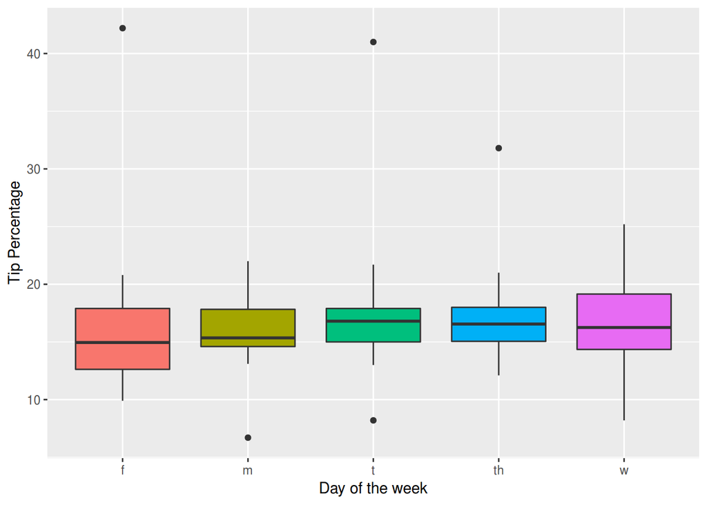

Apparently this restaurant is not open on weekends. In a quest to determine if the average tip percentage varies by day, you run an ANOVA test. Use the results below to answer the following questions.

|  | Df | Sum Sq | Mean Sq | F value | Pr(>F) |
| --- | --- | --- | --- | --- | --- |
| RestaurantTips$Day | 4 | 40.91941 | 10.22985 | 0.5252913 | 0.717291 |
| Residuals | 152 | 2960.14327 | 19.47463 | NA | NA |

1. What is the number of degrees of freedom of the entire dataset?
2. Is there more variation present within groups or between groups in this dataset? How do you know?
3. Does there seem to be statistically significant differences between average tipping percentage across different days of the week?

### Solution

1. The total number of degrees of freedom should be the sum of the two df’s displayed in the table, which would give 156. Note that this is indeed the 157-1 from the total number of rows in our sample that you could have seen in Problem 1.
2. In the `RestaurantTips$Day` line, the Mean Sq column is giving us an idea about the spread of the data between groups. The same column for Residuals gives us an idea about the spread within groups. Here we see that the variation within groups is nearly double the variation between groups, which is going to make it very difficult to determine differences between the groups.
3. As supported by what we said in part b, the F value is 0.52 with a corresponding p-value of 0.71. So there is no evidence to suggest that we reject the null hypothesis, and we remain with the idea that there is no significant difference in tipping across different days of the week.

Sidenote: Technically, we probably should have been a little careful using this data as is, since there is some evidence of extreme outliers. It may have been better to make a note and remove those before proceeding with the ANOVA testing.

## Question 3

### Question

Looking at a dataset of the exercise habits of students, the breakdown of students by gender and hours of weekly exercise is:

|  | Female | Male | Totals |
| --- | --- | --- | --- |
| Less than 5 hours exercise | 10 | 6 | 16 |
| More than 5 hours exercise | 20 | 14 | 34 |
| Totals | 30 | 20 | 50 |

1. What proportion of all students exercises more that 5 hours a week?
2. Test the statement that “More than 60% of students exercise more than 5 hours a week.” Does such a statement have statistical backing?
3. Construct a 95% confidence interval for the proportion of students who exercise more than 5 hours a week.
4. Suppose you wanted to evaluate if there was a statistically significant difference between the proportions of females who exercise more than 5 hours a week and the proportion of males who exercise over 5 hours a week. What conditions must you check and does this data satisfy those conditions?

### Solution

1. 34 out of the 50 students exercise more than 5 hours a week, for a proportion of 0.68.
2. Converting the statement to a hypothesis test would look like:
   $$H_0: \text{60% of students exercise more than 5 hours a week}$$
   $$p = 0.60$$
   $$H_A: \text{More than 60% of students exercise more than 5 hours a week}$$
   $$p > 0.60$$
   Our point estimate in this case in the 0.68 value we found above. Our standard error is given by:
   $$SE = \sqrt{\frac{p(1-p)}{n}} = \sqrt{\frac{0.6\times0.4}{50}} = 0.069282$$
   For proportions I’m using a normal distribution, so my Z-score would be:
   $$Z = \frac{0.68 - 0.60}{0.069282} = 1.1547$$
   Looking this up in a normal distribution table gives a value of 0.8749, which the area *beneath* this Z-score. I actually want the area above this point, since I’m doing a one-tail test here. So my p-value is 1-0.8749 = 0.1251. This is still above the 0.05 significance threshold so I would fail to reject the null hypothesis.
3. I have already found everything I need to construct this interval. Since I’m using a normal distribution I know the critical value for 95% is 1.96.
   $$0.68 \pm 1.96 \times 0.069282 = (0.544, 0.816)$$
   Again, this supports my hypothesis test in that the null value of 0.6 is contained within this range, so I should fail to reject my null hypothesis.
4. We need to check for both independence and normality. For independence, probably the main assumption we need to make is that none of these males or females are couples or friends who enjoy exercising together. So long as that is true though, we are probably safe on the independence front. For a difference between proportions test, we also need to ensure that each group looks nearly normal, which requires that our samples observations are independent *and* that we have 10 successes and failures. Here we see that our female group would squeak by with those qualifications, but our male group fails to have enough members exercising less that 5 hours a week. As such, we should be wary about assuming that that group will be mostly normally distributed.

## Question 4

### Question

Say that you are comparing the results of a drug test on two groups of mice. One group was the control and given a placebo and the other was given the drug in question. The question you are trying to answer is if your drug has effectively reduced the prevalence of some disease in the mice.

1. Would a single tail or a two tail test be more appropriate here?
2. Suppose using whatever method above you found a p-value of 0.15. What does this value represent?
3. In the above situation, you would have concluded that there was not sufficient evidence to reject the null hypothesis. Say later you found convincing evidence to reject the null hypothesis after all. What type of error would you have committed in this original test?

### Solution

1. You are trying to decide if your drug *reduced* the prevalence of some disease in the mice, so you do desire some sort of directionality. This would imply a 1-tail test. It could be argued that you should check against the idea as well that your drug *increased* the prevalence of the disease and thus a two tail test should be used, but usually you’d at least know enough about your drug to assume it was working appropriately.
2. This (and any) p-value represents the probability of getting the result you got in your sample assuming your null hypothesis was true. So here it would be saying that you’d only expect to get this result in a sample 15% of the time if the null hypothesis was true.
3. We essentially decided to fail to reject the null hypothesis when we really should have. This is akin to finding someone innocent when they were really guilty, and is our definition of a Type 2 Error.

## Question 5

### Question

Which of the curves below best describes a normal distribution with a mean of 10 and a standard deviation of 5? How do you know?

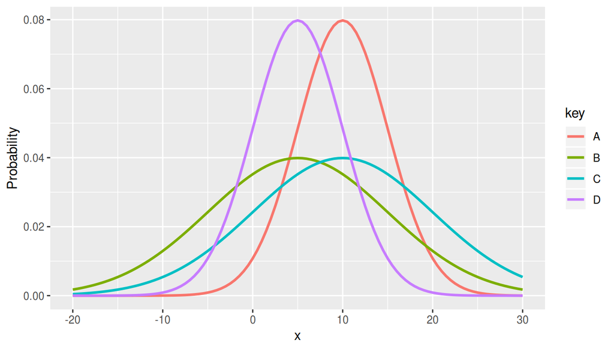